# Ford GoBike TripData Exploration

## Preliminary Wrangling

This analysis is part of the Udacity Dta Analyst Nano Degree and my objective is to demonstrate my data exploration skills.

I've investigated the [proposed datasets](https://video.udacity-data.com/topher/2019/April/5ca78b26_dataset-project-communicate-data-findings/dataset-project-communicate-data-findings.pdf) and choose the Ford GoBike Trip data for my Analysis.

I will start with my **exploratory** analysis where I will gather the data, clean and start exploring the data properties. I will try to answer some questions I have about the dataset.

Using the result from the first part I will do a **explanatory** analysis where I will try to tell a story based on the conclusions I get in the first steps.

I will be using Google Colab environment, in order to not download the data each time I will mount my drive in the notebook (optional).

## Gathering Data

The firs step o data wrangling is aquiring all files neede for the analysis.  
After a short investigation into the [S3 folder](https://s3.amazonaws.com/baywheels-data/index.html) I found a pattern in the file names and I decided to do my analysis on the years 2018 and 2019  
After some trials I foud that from May 2019 the files vendor changed from **fordgobike** to **baywheels**  
Also during the download process I encountered few issues with the autodetected DTypes and the number of columns. All but the last file had 14 columns, so I needed to specify exactly what columns I want to keep

```python
import numpy as np
import pandas as pd
import matplotlib as mlp
import matplotlib.pyplot as plt
import seaborn as sns
import zipfile
import requests
import io
import os.path
import datetime
from dateutil.relativedelta import relativedelta
import sys, traceback


%matplotlib inline
```

### Download GoBike Data between January 2018 and December 2019

The script saves every month data in a local file then concatenate all of them into a big file.  
In order to prevent multiple downloads I check if the file was already downloaded and make sure every file is saved into a known file.

```python
local_path = 'data/'
bike_data_local = 'gobike_data.csv.gz'
zip_url = 'https://s3.amazonaws.com/baywheels-data/{}.zip'
zip_file = '{}-{}-tripdata.csv'
start_date = datetime.date(2018, 1, 1)
months_count = 24
# need to specify columns because 201912 file has some extra fields
csv_cols = ['duration_sec','start_time','end_time','start_station_id',
            'start_station_name','start_station_latitude',
            'start_station_longitude','end_station_id','end_station_name',
            'end_station_latitude','end_station_longitude','bike_id',
            'user_type','bike_share_for_all_trip']
```

(Optional) Mount data already downloaded in Google Drive

```python
# local_path = "/content/gdrive/My Drive/learning/machine-learning/dand/"
# from google.colab import drive
# drive.mount('/content/gdrive')
```

```python
bike_data_local = local_path + bike_data_local

def get_file(date):
    global local_path, bike_data_local
    # the file names are renamed after this date
    if date < '201905':
        file_name = zip_file.format(date, 'fordgobike')
    else:
        file_name = zip_file.format(date, 'baywheels')

    local_file = local_path + str(date) + 'local.csv.gz'
    df = pd.DataFrame([])

    if os.path.isfile(local_file):
        print('Fetch local month ' + date)
        df = pd.read_csv(local_file, low_memory=False, compression='gzip')
    else:
        print ("Downloading: " + zip_url.format(file_name))
        try:
            header = {'user-agent': 'Mozilla/5.0 (Windows NT 10.0; Win64; x64) AppleWebKit/537.36 (KHTML, like Gecko) Chrome/79.0.3945.130 Safari/537.36',}
            remotezip = requests.get(zip_url.format(file_name), headers=header)
            root = zipfile.ZipFile(io.BytesIO(remotezip.content))
            df = pd.read_csv(root.open(file_name), low_memory=False, usecols=csv_cols)
            df.to_csv(local_file, index=False, compression='gzip')
        except:
            exc_type, exc_value, exc_traceback = sys.exc_info()
            traceback.print_tb(exc_traceback, limit=1, file=sys.stdout)
            traceback.print_exception(exc_type, exc_value, exc_traceback,
                                  limit=2, file=sys.stdout)

    return df

if os.path.isfile(bike_data_local):
    print('Load from local {} months file'.format(months_count))
    dfall = pd.read_csv(bike_data_local, low_memory=False, compression='gzip')
else:

    df_list = []
    for i in range(0, months_count):
        crt_date = start_date + relativedelta(months=i)
        df = get_file(crt_date.strftime('%Y%m'))
        df_list.append(df)
        print(df.shape)
    print('Contatenate all months into one file')
    dfall = pd.concat(df_list)
    print('Save {} months file'.format(months_count))
    dfall.to_csv(bike_data_local, index=False, compression='gzip')
```

```
Load from local 24 months file
```

## Assessing Data

During the assesment process we will check for two aspects of the gathered data: **quality** and **tidiness**.  
The quality refers to the issues we have with the content of the data: inaccurate data, corrupted data or duplicated data. Tidiness is related to the structure of the data, Tidy data requires:

- each variable forms a column.
- each observation forms a row.
- each type of observational unit forms a table.

### Visual Assesment

By visually inspecting the datasets we can get acquainted with the data and better understand what is it about

```python
dfall.head()
```

|  | duration_sec | start_time | end_time | start_station_id | start_station_name | start_station_latitude | start_station_longitude | end_station_id | end_station_name | end_station_latitude | end_station_longitude | bike_id | user_type | bike_share_for_all_trip |
| --- | --- | --- | --- | --- | --- | --- | --- | --- | --- | --- | --- | --- | --- | --- |
| 0 | 75284 | 2018-01-31 22:52:35.2390 | 2018-02-01 19:47:19.8240 | 120.0 | Mission Dolores Park | 37.761420 | -122.426435 | 285.0 | Webster St at O'Farrell St | 37.783521 | -122.431158 | 2765 | Subscriber | No |
| 1 | 85422 | 2018-01-31 16:13:34.3510 | 2018-02-01 15:57:17.3100 | 15.0 | San Francisco Ferry Building (Harry Bridges Pl... | 37.795392 | -122.394203 | 15.0 | San Francisco Ferry Building (Harry Bridges Pl... | 37.795392 | -122.394203 | 2815 | Customer | No |
| 2 | 71576 | 2018-01-31 14:23:55.8890 | 2018-02-01 10:16:52.1160 | 304.0 | Jackson St at 5th St | 37.348759 | -121.894798 | 296.0 | 5th St at Virginia St | 37.325998 | -121.877120 | 3039 | Customer | No |
| 3 | 61076 | 2018-01-31 14:53:23.5620 | 2018-02-01 07:51:20.5000 | 75.0 | Market St at Franklin St | 37.773793 | -122.421239 | 47.0 | 4th St at Harrison St | 37.780955 | -122.399749 | 321 | Customer | No |
| 4 | 39966 | 2018-01-31 19:52:24.6670 | 2018-02-01 06:58:31.0530 | 74.0 | Laguna St at Hayes St | 37.776435 | -122.426244 | 19.0 | Post St at Kearny St | 37.788975 | -122.403452 | 617 | Subscriber | No |

### Programatic Assesment

We dig deeper into the data issues by looking programatically at some aspects of the data

```python
dfall.info()
```

```
<class 'pandas.core.frame.DataFrame'>
RangeIndex: 4370704 entries, 0 to 4370703
Data columns (total 14 columns):
duration_sec               int64
start_time                 object
end_time                   object
start_station_id           float64
start_station_name         object
start_station_latitude     float64
start_station_longitude    float64
end_station_id             float64
end_station_name           object
end_station_latitude       float64
end_station_longitude      float64
bike_id                    int64
user_type                  object
bike_share_for_all_trip    object
dtypes: float64(6), int64(2), object(6)
memory usage: 466.8+ MB
```

```python
dfall.describe()
```

|  | duration_sec | start_station_id | start_station_latitude | start_station_longitude | end_station_id | end_station_latitude | end_station_longitude | bike_id |
| --- | --- | --- | --- | --- | --- | --- | --- | --- |
| count | 4.370704e+06 | 4.278199e+06 | 4.370704e+06 | 4.370704e+06 | 4.276031e+06 | 4.370704e+06 | 4.370704e+06 | 4.370704e+06 |
| mean | 8.288215e+02 | 1.348904e+02 | 3.776580e+01 | -1.223496e+02 | 1.320798e+02 | 3.776536e+01 | -1.223471e+02 | 1.698155e+04 |
| std | 2.152483e+03 | 1.141269e+02 | 1.242493e-01 | 2.577378e-01 | 1.134725e+02 | 1.939181e-01 | 5.469663e-01 | 8.772065e+04 |
| min | 6.000000e+01 | 3.000000e+00 | 0.000000e+00 | -1.225143e+02 | 3.000000e+00 | 0.000000e+00 | -1.225143e+02 | 4.000000e+00 |
| 25% | 3.550000e+02 | 4.200000e+01 | 3.777008e+01 | -1.224117e+02 | 3.600000e+01 | 3.777041e+01 | -1.224113e+02 | 1.553000e+03 |
| 50% | 5.640000e+02 | 9.700000e+01 | 3.778079e+01 | -1.223983e+02 | 9.300000e+01 | 3.778101e+01 | -1.223974e+02 | 3.004000e+03 |
| 75% | 8.810000e+02 | 2.130000e+02 | 3.779539e+01 | -1.222902e+02 | 2.050000e+02 | 3.779625e+01 | -1.222914e+02 | 5.104000e+03 |
| max | 9.121100e+05 | 4.980000e+02 | 4.551000e+01 | 0.000000e+00 | 4.980000e+02 | 4.551000e+01 | 0.000000e+00 | 9.999410e+05 |

Check distinct stations and their ride count

```python
dfall.start_station_name.value_counts()
```

```
Market St at 10th St                                         79976
San Francisco Ferry Building (Harry Bridges Plaza)           77477
Berry St at 4th St                                           76678
San Francisco Caltrain (Townsend St at 4th St)               75394
San Francisco Caltrain Station 2  (Townsend St at 4th St)    74193
                                                             ...
Prototype Lab                                                    4
Mercado Way at Sierra Rd                                         3
San Jose Depot                                                   3
Philly Demo                                                      2
SF Test Station                                                  1
Name: start_station_name, Length: 474, dtype: int64
```

Check distinct bilekes and the amount of rides they made.  
Turns out there are 12k bikes, some of them almost made 1900 rides

```python
dfall.bike_id.value_counts()
```

```
3379      1889
3381      1809
3670      1801
1181      1776
3589      1768
          ...
12985        1
11442        1
582534       1
6304         1
809335       1
Name: bike_id, Length: 12028, dtype: int64
```

Check for duplicated lines - they are none

```python
dfall[dfall.duplicated()]
```

|  | duration_sec | start_time | end_time | start_station_id | start_station_name | start_station_latitude | start_station_longitude | end_station_id | end_station_name | end_station_latitude | end_station_longitude | bike_id | user_type | bike_share_for_all_trip |
| --- | --- | --- | --- | --- | --- | --- | --- | --- | --- | --- | --- | --- | --- | --- |

Check null values

```python
dfall.isnull().sum()
```

```
duration_sec                    0
start_time                      0
end_time                        0
start_station_id            92505
start_station_name          91904
start_station_latitude          0
start_station_longitude         0
end_station_id              94673
end_station_name            94121
end_station_latitude            0
end_station_longitude           0
bike_id                         0
user_type                       0
bike_share_for_all_trip    101066
dtype: int64
```

Turns out there are some rides that are not between stations, the bikes are left in other places.

Also there is a program called "Bike Share for All" which gives a $5 anual membership for qualifying residents.

```python
dfall['bike_share_for_all_trip'].value_counts()
```

```
No      3904970
Yes      344896
1995       1657
1994       1470
1985       1357
1996       1228
1993       1112
1991       1036
1988        792
1990        741
1984        715
1992        690
1997        687
1989        568
1983        563
```

[output cut: 46 more lines]

Further investigating, the field includes mostly Yes|No values, but also some numbers that look like birth years.

```python
dfall[(dfall['bike_share_for_all_trip'] != 'Yes')
      & (dfall['bike_share_for_all_trip'] != 'No')
      & ~dfall['bike_share_for_all_trip'].isnull()]['bike_share_for_all_trip'].count()
```

```
19772
```

There are ~20k rides with numeric values instead of Yes|No for the bike_share_for_all_trip field

```python
dfall.user_type.value_counts()
```

```
Subscriber    3604720
Customer       765984
Name: user_type, dtype: int64
```

```python
print(dfall [ (dfall.start_station_latitude == 0) | (dfall.start_station_longitude == 0) ].start_station_name.unique())
print(dfall [ (dfall.end_station_latitude == 0) | (dfall.end_station_longitude == 0) ].end_station_name.unique())
```

```
['SF Test Station' '16th Depot Bike Fleet Station']
['SF Test Station' '16th Depot Bike Fleet Station']
```

Should remove rides to and from this stations

## Structure of the dataset

- **duration_sec** - int64 - Duration of the ride in seconds
- **start_time** - object - The start time of the ride
- **end_time** - object - The end time of the ride
- **start_station_id** - float64 - The start station id or Null if not started in a station
- **start_station_name** - object - The start station name
- **start_station_latitude** - float64 - The start station latitude
- **start_station_longitude** - float64 - The start station longitude
- **end_station_id** - float64 - The end station id or Null if not left the bike in a station
- **end_station_name** - object - The end station name
- **end_station_latitude** - float64 - The end station latitude
- **end_station_longitude** - float64 - The end station longitude
- **bike_id** - int64 - The bike id
- **user_type** - object - A value determining if the user is a Subscriber or Customer
- **bike_share_for_all_trip** - object - Yes|No user is in the "Bake Sharing for all" promotion

### Features of interest

I will use in my analysis all of the features in the dataset. In order to see details about trips will have to use `start_time`, `end_time`, `duration_sec` and derived features hour, day, weekday). For answering questions about the bikes I will use `bike_id`, `start_station_id`. To find how many subscribers there are and if they use some offers I will use `user_type` and `bike_share_for_all_trip`. I will use `start_station_id`, `start_station_name`, `end_station_id`, `end_station_name` to compute stats about stations. In order to identify the `start_city` and `end_city` I will use `start_station_latitude`, `start_station_longitude`, `end_station_latitude`, `end_station_longitude`

## Quality issues

Here I try to identify all issues with the datasets

### Tidiness

- Identify City by coordinates

### Quality

- **bike_share_for_all_trip** - handle values that are not Yes|No ✓
- **start_time** - convert to datetime ✓
- **end_time** - convert to datetime ✓
- check duration_sec is equal to end-time - start_time in seconds ✓
- **start_station_id**, **end_station_id**, **bike_id** - convert to string because they are not ordinal ✓
- **bike_share_for_all_trip** - convert to categorical ✓
- **user_type** - convert to categorical ✓
- remove rides to and from this stations: 'SF Test Station', '16th Depot Bike Fleet Station' because they have coordinates equal to 0 ✓

## Cleaning Data

Address all found quality issues

But first make a copy of the dataframe

```python
df_clean = dfall.copy()
```

### Fields conversions

```python
df_clean.start_time = pd.to_datetime(df_clean.start_time)
df_clean.end_time = pd.to_datetime(df_clean.end_time)
```

```python
assert pd.api.types.is_datetime64_ns_dtype(df_clean.start_time)
assert pd.api.types.is_datetime64_ns_dtype(df_clean.end_time)
```

```python
df_clean.start_station_id = df_clean.start_station_id.astype(str).replace('nan',np.nan)
df_clean.end_station_id = df_clean.end_station_id.astype(str).replace('nan',np.nan)
df_clean.bike_id = df_clean.bike_id.astype(str).replace('nan',np.nan)
```

```python
assert pd.api.types.is_string_dtype(df_clean.start_station_id)
assert pd.api.types.is_string_dtype(df_clean.end_station_id)
assert pd.api.types.is_string_dtype(df_clean.bike_id)
```

```python
df_clean.bike_share_for_all_trip = df_clean.bike_share_for_all_trip.astype('str').replace({'\d+': np.nan, 'nan': np.nan}, regex=True).astype('category')
df_clean.bike_share_for_all_trip.unique()
```

```
[No, Yes, NaN]
Categories (2, object): [No, Yes]
```

```python
df_clean.user_type = df_clean.user_type.astype('category')
df_clean.user_type.unique()
```

```
[Subscriber, Customer]
Categories (2, object): [Subscriber, Customer]
```

```python
bad_stations = ['SF Test Station', '16th Depot Bike Fleet Station']
df_clean = df_clean[~df_clean.start_station_name.isin(bad_stations)]
df_clean = df_clean[~df_clean.end_station_name.isin(bad_stations)]

assert df_clean[df_clean.start_station_name.isin(bad_stations)].shape[0] == 0
assert df_clean[df_clean.end_station_name.isin(bad_stations)].shape[0] == 0
```

### Data validation

```python
df_clean['actual_duration_sec'] = (df_clean['end_time'] - df_clean['start_time']).dt.seconds
df_clean['duration_sec_diff'] = df_clean['duration_sec'] - df_clean['actual_duration_sec']

df_clean['duration_sec_diff'].unique()
```

```
array([     0,  -3600,   3600, -82800,     -1, 864000])
```

```python
df_clean[(df_clean['duration_sec_diff'] > 1) | (df_clean['duration_sec_diff'] < -1)]['start_time'].dt.date.unique()
```

```
array([datetime.date(2018, 3, 10), datetime.date(2018, 3, 11),
       datetime.date(2018, 11, 3), datetime.date(2018, 11, 4),
       datetime.date(2019, 3, 9), datetime.date(2019, 3, 10),
       datetime.date(2019, 11, 2), datetime.date(2019, 11, 3),
       datetime.date(2019, 12, 19)], dtype=object)
```

```python
df_clean[df_clean['duration_sec_diff'] > 3600]
```

|  | duration_sec | start_time | end_time | start_station_id | start_station_name | start_station_latitude | start_station_longitude | end_station_id | end_station_name | end_station_latitude | end_station_longitude | bike_id | user_type | bike_share_for_all_trip | actual_duration_sec | duration_sec_diff |
| --- | --- | --- | --- | --- | --- | --- | --- | --- | --- | --- | --- | --- | --- | --- | --- | --- |
| 4344997 | 912110 | 2019-12-19 23:15:36 | 2019-12-30 12:37:26 | NaN | NaN | 37.323757 | -121.878614 | NaN | NaN | 37.327656 | -121.868598 | 614329 | Customer | NaN | 48110 | 864000 |

Remove outlier trip that took more than 10 days

```python
df_clean = df_clean[df_clean['duration_sec'] != 912110]
```

```python
df_clean.drop(['actual_duration_sec', 'duration_sec_diff'], axis=1, inplace=True)
```

The differences are:

- 0 is ok
- -1 probably because of some conversion
- -3600, 3600, -82800 - because [daylight saving](https://www.timeanddate.com/time/change/usa/san-francisco?year=2019) and the dates confirm
- 864000 - dt.seconds doesn't work for [more than a day](https://pandas.pydata.org/pandas-docs/stable/reference/api/pandas.Series.dt.seconds.html)

Conclusion: all duration_sec values are ok

## Feature engineering

**Identify City**

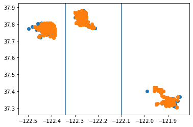

```python
df_clean_sample = df_clean.sample(n=10000)
plt.scatter('start_station_longitude', 'start_station_latitude', data=df_clean_sample)
plt.scatter('end_station_longitude', 'end_station_latitude', data=df_clean_sample);
plt.axvline(-122.34)
plt.axvline(-122.1);
```

Assign Cities based on map and coordinates https://member.baywheels.com/map/

```python
df_clean['start_city'] = 'East Bay'
df_clean['end_city'] = 'East Bay'

df_clean.loc[df_clean['start_station_longitude'] < -122.34, 'start_city'] = 'San Francisco'
df_clean.loc[df_clean['end_station_longitude'] < -122.34, 'end_city'] = 'San Francisco'
df_clean.loc[df_clean['start_station_longitude'] > -122.1, 'start_city'] = 'San Jose'
df_clean.loc[df_clean['end_station_longitude'] > -122.1, 'end_city'] = 'San Jose'

df_clean['start_city'] = df_clean['start_city'].astype('category')
df_clean['end_city'] = df_clean['end_city'].astype('category')
```

```python
df_clean['start_city'].value_counts()
```

```
San Francisco    3215467
East Bay          917550
San Jose          237594
Name: start_city, dtype: int64
```

**Compute duration in minutes**

```python
df_clean['duration_min'] = df_clean['duration_sec']/60
```

**Compute some other usefull features**

```python
df_clean['date'] = df_clean['start_time'].dt.date
df_clean['hour'] = df_clean['start_time'].dt.hour
df_clean['dayofweek'] = df_clean['start_time'].dt.dayofweek
```

**Build some aggregated datasets based on the initial one**

```python
df_aggregated = df_clean.groupby('start_city').agg(
    unique_bikes= ('bike_id', 'nunique'),
    trips_count= ('start_city', 'count'),
    unique_stations= ('start_station_id', 'nunique'),
    total_time_min= ('duration_min', 'sum')
).reset_index()
df_aggregated
```

|  | start_city | unique_bikes | trips_count | unique_stations | total_time_min |
| --- | --- | --- | --- | --- | --- |
| 0 | East Bay | 3929 | 917550 | 130 | 1.141375e+07 |
| 1 | San Francisco | 8384 | 3215467 | 225 | 4.584791e+07 |
| 2 | San Jose | 3233 | 237594 | 88 | 3.067162e+06 |

```python
df_clean['user_type_Customer'] = df_clean['user_type'] == 'Customer'
df_clean['user_type_Subscriber'] = df_clean['user_type'] == 'Subscriber'
df_clean['use_bike_share'] = df_clean['bike_share_for_all_trip'] == 'Yes'
df_clean['is_work_day'] = (df_clean['dayofweek'] < 5).astype(int)
df_clean['is_weekend'] = (df_clean['dayofweek'] > 4).astype(int)

df_agg_by_date = df_clean.groupby('date').agg(
    unique_bikes= ('bike_id', 'nunique'),
    trips_count= ('start_city', 'count'),
    unique_stations= ('start_station_id', 'nunique'),
    duration_mean= ('duration_min', 'mean'),
    duration_total= ('duration_min', 'sum'),
    customer_count= ('user_type_Customer', 'sum'),
    subscriber_count= ('user_type_Subscriber', 'sum'),
    use_bike_share= ('use_bike_share', 'sum'),
    is_work_day= ('is_work_day', 'first'),
    is_weekend= ('is_weekend', 'first'),
).reset_index()
```

Sort dataframe by trip time

```python
df_clean.sort_values(by=['start_time', 'end_time']).reset_index(inplace=True)
```

### Save the cleand dataset

```python
clean_file = local_path + 'gobike_clean_data.csv.gz'
if not os.path.isfile(clean_file):
    df_clean.to_csv(clean_file, index=False, compression='gzip')
```

## Exploratory Data Analysis

Questions:

- What is the trips evolution in time?
- How are the stations, bikes and trips split per city?
- How many trips between cities we have?
- What is the ratio of the Customers vs Subscribers?
- What are the busiest hours in the day?
- Distribution of the durations of the trips?
- What is the bikes usage distribution?
- How many stations the most used bikes passed throug?
- What is the busiest hours for each week day?
- What are the top 10 most frequent routes?
- What are the top 5 busiest stations in each city?
- Top trips destination?
- How correlated are the features?

```python
FIG_HEIGHT=7
FIG_WIDTH_SMALL = 7
FIG_WIDTH_MEDIUM = 10
FIG_WIDTH_LARGE = 15
```

### Univariate Exploration¶

**What is the trips evolution in time?**

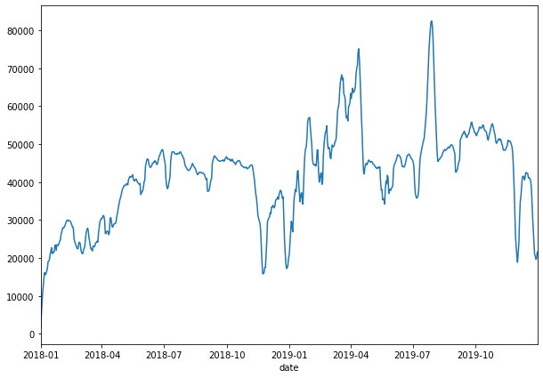

```python
plt.figure(figsize=(FIG_WIDTH_MEDIUM,FIG_HEIGHT))
df_clean_by_date = df_clean.groupby(['date'])['start_time'].count()
df_by_date_rolling = df_clean_by_date.rolling(7, min_periods=1).sum()

df_by_date_rolling.plot();
df_clean_by_date.sort_values();
```

The trips count has an increasing trend in this years, there is less bike traffic during the holidays and increasing in the spring. There is a peak on July 23-26 2019, probably due some event and a fas increasing trend starting at the beginning of 2019

**How are the stations, bikes and trips split per city?**

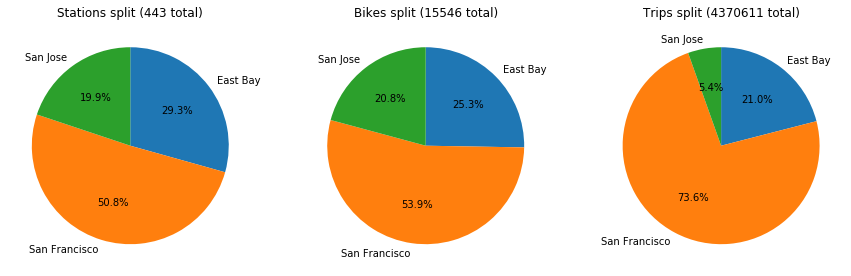

```python
fig, ax = plt.subplots(1, 3, figsize=(FIG_WIDTH_LARGE, FIG_HEIGHT))
sections = [
            ('unique_stations', 'Stations'),
            ('unique_bikes', 'Bikes'),
            ('trips_count', 'Trips'),
]
for i in range(len(sections)):
    el = sections[i]
    ax[i].pie(df_aggregated[el[0]], labels = df_aggregated['start_city'],
            startangle = 90, counterclock = False, autopct='%1.1f%%',
            # textprops={'color':"w", 'weight':'bold'}
            );
    ax[i].set_title(el[1] + ' split (' + str(df_aggregated[el[0]].sum()) + ' total)')
```

It is obvious San Francisco has the most bikes from this cities, it has more then half of them. There are even more bike stations compared to the other cities, but this makes sense because there are a lot more rides than in the other cities 73.6%.

```python
df_aggregated['total_time_min']/df_aggregated['unique_bikes']
```

```
0    2905.001455
1    5468.501054
2     948.704722
dtype: float64
```

**How many trips between cities we have?**

```python
between_cities_trips = df_clean[df_clean['start_city'] != df_clean['end_city']]['start_city'].count()
print('There are ' + str(between_cities_trips) + ' trips between cities')
```

```
There are 220 trips between cities
```

It seems there are not that many trips between the cities, probably the distance is big enough.

**What is the ratio of the Customers vs Subscribers?**

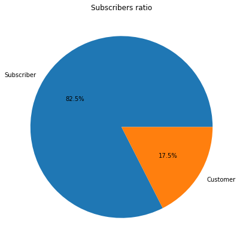

```python
plt.figure(figsize=(FIG_WIDTH_MEDIUM,FIG_HEIGHT))
user_types_count=df_clean.user_type.value_counts()
plt.pie(user_types_count, labels = user_types_count.index, autopct='%1.1f%%');
plt.title('Subscribers ratio');
```

It seems the majority of the trips are taken by the subscribers. [Subscriptions](https://www.lyft.com/bikes/bay-wheels/pricing) are pretty cheap probably people prefer them instead of Single Rides or daily Access Pass.

**What is the ratio users using the "Bike Sharing for all" promotion?**

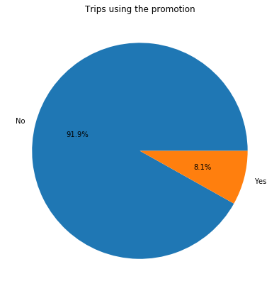

```python
plt.figure(figsize=(FIG_WIDTH_MEDIUM,FIG_HEIGHT))
user_types_count=df_clean.bike_share_for_all_trip.value_counts()
plt.pie(user_types_count, labels = user_types_count.index, autopct='%1.1f%%');
plt.title('Trips using the promotion');
```

The percentage is probably low because the program is for residents who qualify to the program. The requirement is [CalFresh eligibility](http://www.publiccounsel.org/pages/?id=0090) this implies mostly old and low income people.

```python
df_day_week = df_clean.groupby(['dayofweek', 'hour']).size().reset_index()
```

**What are the busiest hours in the day?**

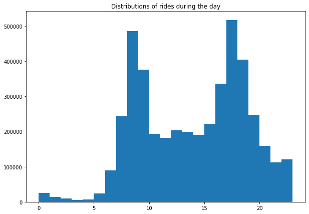

```python
plt.figure(figsize = (FIG_WIDTH_MEDIUM,FIG_HEIGHT))

plt.hist(data = df_clean, x = 'hour', bins=23);
plt.title('Distributions of rides during the day');
```

The peak hours are 8-9 in the morning and 17-18 in the afternoon, probably because a lot of people use this bikes for comutes to and from work. During the night is very low as expected.

**Distribution of the durations of the trips?**

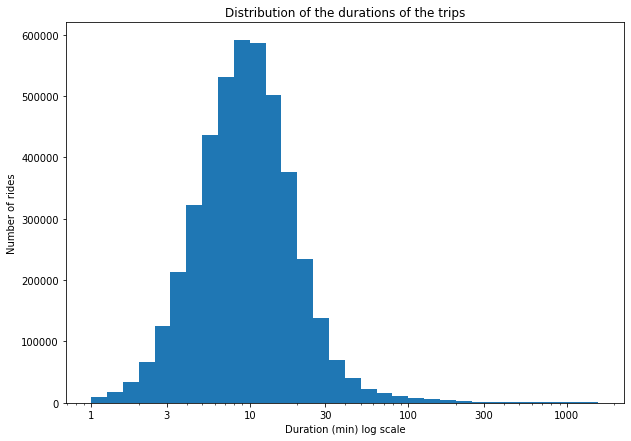

```python
plt.figure(figsize = (FIG_WIDTH_MEDIUM,FIG_HEIGHT))

data = df_clean.duration_min
bins = 10 ** np.arange(np.log10(data.min()), np.log10(data.max())+0.1, 0.1)
ticks = [1, 3, 10, 30, 100, 300, 1000]

plt.hist(x=data, bins=bins)
plt.title('Distribution of the durations of the trips')
plt.ylabel('Number of rides')
plt.xscale('log')
plt.xticks(ticks, ticks)
plt.xlabel('Duration (min) log scale');
```

The majority of the rides seem to be between 5 and 20 minutes The payment options include 30min or 45min rides per pay with extra costs for every aditional 15min.

```python
under45 = df_clean[df_clean.duration_min <= 45].duration_min.count() / \
df_clean.duration_min.count()

under30 = df_clean[df_clean.duration_min <= 30].duration_min.count() / \
df_clean.duration_min.count()

print("%.0f%% of rides are under 30 minutes and %.0f%% of the rides are under 45 minutes" % ( under30 * 100, under45 * 100 ))
```

```
95% of rides are under 30 minutes and 98% of the rides are under 45 minutes
```

```python
print("90%% of the rides have between %.2f and %.2f minutes" % (
    df_clean.duration_min.quantile(0.05),
    df_clean.duration_min.quantile(0.95)
))
```

```
90% of the rides have between 3.00 and 29.72 minutes
```

**What is the bikes usage distribution?**

```python
bikes_agg = df_clean.groupby(['bike_id']).agg(
    trips_count = ('start_time', 'count'),
    unique_stations= ('start_station_id', 'nunique'),
).sort_values('trips_count', ascending=False).reset_index()
```

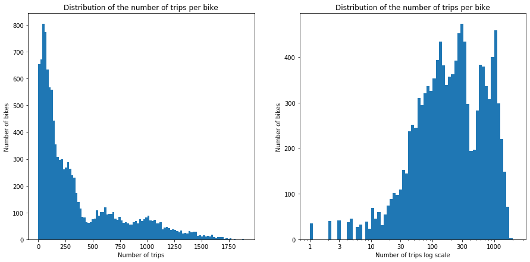

```python
fig, ax = plt.subplots(1, 2, figsize=(FIG_WIDTH_LARGE, FIG_HEIGHT))

data = bikes_agg.trips_count
bins = 10 ** np.arange(np.log10(data.min()), np.log10(data.max())+0.1, 0.05)
ticks = [1, 3, 10, 30, 100, 300, 1000]

ax[0].hist(data, bins=100)
ax[0].set_title('Distribution of the number of trips per bike')
ax[0].set_ylabel('Number of bikes')
ax[0].set_xlabel('Number of trips');

ax[1].hist(data, bins=bins)
ax[1].set_title('Distribution of the number of trips per bike')
ax[1].set_ylabel('Number of bikes')
ax[1].set_xscale('log')
ax[1].set_xticks(ticks)
ax[1].set_xticklabels(ticks)
ax[1].set_xlabel('Number of trips log scale');
```

Exploring the bike usage statistics, we see a lo of bikes with usage under 300 times. I tried a logaritmic scale to see what happens for smaller values. It seems there are 4 peaks in the graph, around 100, 300, 600 and 1000, this might look like this because of 4 different batches of bikes introduced artificially

```python
bikes_agg_per_city = df_clean.groupby(['start_city', 'bike_id']).agg(
    trips_count = ('start_time', 'count'),
    unique_stations= ('start_station_id', 'nunique'),
).sort_values('trips_count', ascending=False).reset_index()
```

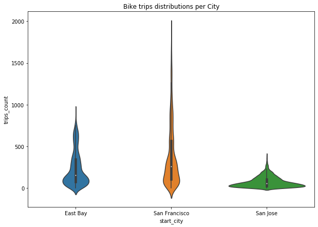

```python
plt.figure(figsize = (FIG_WIDTH_MEDIUM,FIG_HEIGHT))

sns.violinplot(data = bikes_agg_per_city, x = 'start_city', y = 'trips_count');
plt.title('Bike trips distributions per City');
```

The distributions look different for each City, this might be due to different usage patterns or maybe the program was introduced in different points in time.

**How many stations the most used bikes passed through?**

```python
top_bikes = bikes_agg_per_city.head(15).copy()
sf_top_stations = df_aggregated[df_aggregated['start_city'] == top_bikes['start_city'][0]]['unique_stations']
top_bikes['stations_percent'] = top_bikes['unique_stations'].divide(int(sf_top_stations))

top_bikes
```

|  | start_city | bike_id | trips_count | unique_stations | stations_percent |
| --- | --- | --- | --- | --- | --- |
| 0 | San Francisco | 3379 | 1889 | 166 | 0.737778 |
| 1 | San Francisco | 3381 | 1809 | 167 | 0.742222 |
| 2 | San Francisco | 3670 | 1801 | 162 | 0.720000 |
| 3 | San Francisco | 1181 | 1775 | 170 | 0.755556 |
| 4 | San Francisco | 3589 | 1768 | 168 | 0.746667 |
| 5 | San Francisco | 1396 | 1763 | 171 | 0.760000 |
| 6 | San Francisco | 3146 | 1757 | 168 | 0.746667 |
| 7 | San Francisco | 3105 | 1741 | 166 | 0.737778 |
| 8 | San Francisco | 3386 | 1741 | 167 | 0.742222 |
| 9 | San Francisco | 1182 | 1725 | 166 | 0.737778 |
| 10 | San Francisco | 3729 | 1722 | 164 | 0.728889 |
| 11 | San Francisco | 3334 | 1720 | 163 | 0.724444 |
| 12 | San Francisco | 1406 | 1720 | 164 | 0.728889 |
| 13 | San Francisco | 2692 | 1705 | 170 | 0.755556 |
| 14 | San Francisco | 3242 | 1698 | 162 | 0.720000 |

```python
print("Top 15 bikes visited %.0f%% of the stations." %
      (top_bikes.stations_percent.mean()*100))
```

```
Top 15 bikes visited 74% of the stations.
```

```python
df_clean
```

|  | duration_sec | start_time | end_time | start_station_id | start_station_name | start_station_latitude | start_station_longitude | end_station_id | end_station_name | end_station_latitude | ... | end_city | duration_min | date | hour | dayofweek | user_type_Customer | user_type_Subscriber | use_bike_share | is_work_day | is_weekend |
| --- | --- | --- | --- | --- | --- | --- | --- | --- | --- | --- | --- | --- | --- | --- | --- | --- | --- | --- | --- | --- | --- |
| 0 | 75284 | 2018-01-31 22:52:35.239 | 2018-02-01 19:47:19.824 | 120.0 | Mission Dolores Park | 37.761420 | -122.426435 | 285.0 | Webster St at O'Farrell St | 37.783521 | ... | San Francisco | 1254.733333 | 2018-01-31 | 22 | 2 | False | True | False | 1 | 0 |
| 1 | 85422 | 2018-01-31 16:13:34.351 | 2018-02-01 15:57:17.310 | 15.0 | San Francisco Ferry Building (Harry Bridges Pl... | 37.795392 | -122.394203 | 15.0 | San Francisco Ferry Building (Harry Bridges Pl... | 37.795392 | ... | San Francisco | 1423.700000 | 2018-01-31 | 16 | 2 | True | False | False | 1 | 0 |
| 2 | 71576 | 2018-01-31 14:23:55.889 | 2018-02-01 10:16:52.116 | 304.0 | Jackson St at 5th St | 37.348759 | -121.894798 | 296.0 | 5th St at Virginia St | 37.325998 | ... | San Jose | 1192.933333 | 2018-01-31 | 14 | 2 | True | False | False | 1 | 0 |
| 3 | 61076 | 2018-01-31 14:53:23.562 | 2018-02-01 07:51:20.500 | 75.0 | Market St at Franklin St | 37.773793 | -122.421239 | 47.0 | 4th St at Harrison St | 37.780955 | ... | San Francisco | 1017.933333 | 2018-01-31 | 14 | 2 | True | False | False | 1 | 0 |
| 4 | 39966 | 2018-01-31 19:52:24.667 | 2018-02-01 06:58:31.053 | 74.0 | Laguna St at Hayes St | 37.776435 | -122.426244 | 19.0 | Post St at Kearny St | 37.788975 | ... | San Francisco | 666.100000 | 2018-01-31 | 19 | 2 | False | True | False | 1 | 0 |
| ... | ... | ... | ... | ... | ... | ... | ... | ... | ... | ... | ... | ... | ... | ... | ... | ... | ... | ... | ... | ... | ... |
| 4370699 | 731 | 2019-12-28 18:37:29.000 | 2019-12-28 18:49:40.000 | NaN | NaN | 37.809731 | -122.409855 | NaN | NaN | 37.807573 | ... | San Francisco | 12.183333 | 2019-12-28 | 18 | 5 | False | True | False | 0 | 1 |
| 4370700 | 748 | 2019-12-28 18:37:24.000 | 2019-12-28 18:49:53.000 | NaN | NaN | 37.809768 | -122.409797 | NaN | NaN | 37.807558 | ... | San Francisco | 12.466667 | 2019-12-28 | 18 | 5 | False | True | False | 0 | 1 |
| 4370701 | 1044 | 2019-12-26 14:25:37.000 | 2019-12-26 14:43:02.000 | NaN | NaN | 37.810183 | -122.410271 | NaN | NaN | 37.807225 | ... | San Francisco | 17.400000 | 2019-12-26 | 14 | 3 | False | True | False | 1 | 0 |
| 4370702 | 326 | 2019-12-30 20:35:43.000 | 2019-12-30 20:41:09.000 | NaN | NaN | 37.810471 | -122.417386 | NaN | NaN | 37.803143 | ... | San Francisco | 5.433333 | 2019-12-30 | 20 | 0 | False | True | False | 1 | 0 |
| 4370703 | 4023 | 2019-12-31 19:26:48.000 | 2019-12-31 20:33:52.000 | NaN | NaN | 37.811042 | -122.418149 | NaN | NaN | 37.810970 | ... | San Francisco | 67.050000 | 2019-12-31 | 19 | 1 | False | True | False | 1 | 0 |

4370611 rows × 25 columns

### Discuss the distribution(s) of your variable(s) of interest. Were there any unusual points? Did you need to perform any transformations?

I started with duration_sec and converted it to minutes for easier understanding.  
I tried to view a histogram of the duration_min feature, but it was very right skewed so I tried a logarithmic scale. Turns out that duration_min has a log-normal distribution.  
When I took a look at how many trips we have per bike, the initial history was pretty right skewed so I tried log scale.  
The logarithmic scale distriburion is left skewed and it has few spikes around: 100, 300, 600 and 1000. For this my supposition is that the bikes were introduced in 4 batches and this is how er have like 4 distribtions overlapping.  
I also took a look on the distributions of the tripes per bike in each city and I noticed there are different distribtions with one or 3 bike batches.  
The distribution for the trips hours have to spikes when the comute hours are.

### Of the features you investigated, were there any unusual distributions? Did you perform any operations on the data to tidy, adjust, or change the form of the data? If so, why did you do this?

The only features with tydiness problems were some stations that had coordinates as 0, I couldn't identify the original points so I delete them. The rest of the features of inderest didn't have outlier in the distributions and I didn't need to perform any data tidy operations on them.  
There were some qualities issues for some fields because didn't have the proper types and I converted them to the correct one.

### Bivariate Exploration¶

**What is the busiest hours for each week day?**

The busiest hours during the woeking days are around 9 and 17, but during the weekends the traffic is a lot smaller andand the peak is around noon

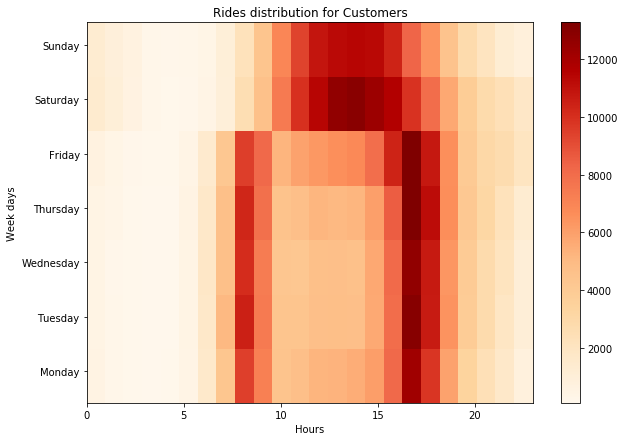

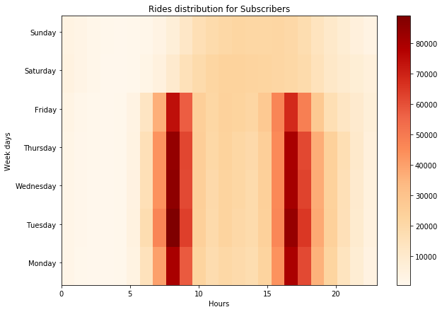

```python
def ride_distribtion(df, name):

    plt.figure(figsize = (FIG_WIDTH_MEDIUM,FIG_HEIGHT))

    plt.hist2d(df['hour'], df['dayofweek'], bins = [24, 7],
               cmap = 'OrRd', cmin = 0.5)
    plt.title('Rides distribution for ' + name)
    plt.xlabel('Hours')
    plt.ylabel('Week days')
    plt.yticks(np.arange(0.5, 6.5, step=6/7),
         ('Monday', 'Tuesday', 'Wednesday', 'Thursday', 'Friday', 'Saturday', 'Sunday'));
    plt.colorbar();
    plt.show();

ride_distribtion(df_clean[df_clean['user_type'] == 'Customer'].copy(), 'Customers')
ride_distribtion(df_clean[df_clean['user_type'] == 'Subscriber'].copy(), 'Subscribers')
```

By looking at the distribution of rides for every hour of the week days we can see the peaks during comuting times.  
If we plot separately for Customers vs Subscribers we cans see that the Customers trend to also have more rides during the weekends, probably turists and people who don't use bikes that often to by a subscription ride more during the weekends.

**What are the top 10 most frequent routes?**

```python
top_10_freq_routes = df_clean.groupby(['start_station_id', 'end_station_id']).agg(
    trips_count = ('start_time', 'count'),
    start_station_name = ('start_station_name', 'first'),
    end_station_name = ('end_station_name', 'first'),
).sort_values('trips_count', ascending=False).reset_index()
```

```python
top_10_freq_routes[0:10][['start_station_name', 'end_station_name','trips_count']]
```

|  | start_station_name | end_station_name | trips_count |
| --- | --- | --- | --- |
| 0 | San Francisco Ferry Building (Harry Bridges Pl... | The Embarcadero at Sansome St | 12676 |
| 1 | Berry St at 4th St | San Francisco Ferry Building (Harry Bridges Pl... | 9416 |
| 2 | The Embarcadero at Sansome St | Steuart St at Market St | 8619 |
| 3 | Grand Ave at Perkins St | 19th Street BART Station | 7651 |
| 4 | 19th Street BART Station | Grand Ave at Perkins St | 7121 |
| 5 | The Embarcadero at Sansome St | San Francisco Ferry Building (Harry Bridges Pl... | 6999 |
| 6 | San Francisco Ferry Building (Harry Bridges Pl... | Berry St at 4th St | 6445 |
| 7 | Steuart St at Market St | The Embarcadero at Sansome St | 6032 |
| 8 | Bryant St at 2nd St | Montgomery St BART Station (Market St at 2nd St) | 5904 |
| 9 | Market St at 10th St | Powell St BART Station (Market St at 4th St) | 5662 |

The most popular route is between "San Francisco Ferry Building" and "The Embarcadero at Sansome St". the station "San Francisco Ferry Building" is one of the end of 4 int the top 10 list.

**Top trips destination?**

```python
top_5_busy_stations = df_clean.groupby(['start_city', 'end_station_id']).agg(
    trips_count = ('start_time', 'count'),
    start_station_name = ('end_station_name', 'first')
).sort_values('trips_count', ascending=False).reset_index()

top_5_busy_stations.groupby(['start_city']).head(5)
```

|  | start_city | end_station_id | trips_count | start_station_name |
| --- | --- | --- | --- | --- |
| 0 | San Francisco | 67.0 | 102146.0 | San Francisco Caltrain Station 2 (Townsend St... |
| 1 | San Francisco | 30.0 | 93913.0 | San Francisco Caltrain (Townsend St at 4th St) |
| 2 | San Francisco | 15.0 | 92280.0 | San Francisco Ferry Building (Harry Bridges Pl... |
| 3 | San Francisco | 21.0 | 83834.0 | Montgomery St BART Station (Market St at 2nd St) |
| 4 | San Francisco | 58.0 | 78648.0 | Market St at 10th St |
| 18 | East Bay | 182.0 | 35934.0 | 19th Street BART Station |
| 22 | East Bay | 176.0 | 30320.0 | MacArthur BART Station |
| 26 | East Bay | 245.0 | 28812.0 | Downtown Berkeley BART |
| 33 | East Bay | 239.0 | 25736.0 | Bancroft Way at Telegraph Ave |
| 54 | East Bay | 197.0 | 21270.0 | El Embarcadero at Grand Ave |
| 79 | San Jose | 310.0 | 16746.0 | San Fernando St at 4th St |
| 81 | San Jose | 296.0 | 16650.0 | 5th St at Virginia St |
| 111 | San Jose | 280.0 | 13016.0 | San Fernando at 7th St |
| 117 | San Jose | 312.0 | 12315.0 | San Jose Diridon Station |
| 147 | San Jose | 317.0 | 9041.0 | San Salvador St at 9th St |

**How correlated are the features?**

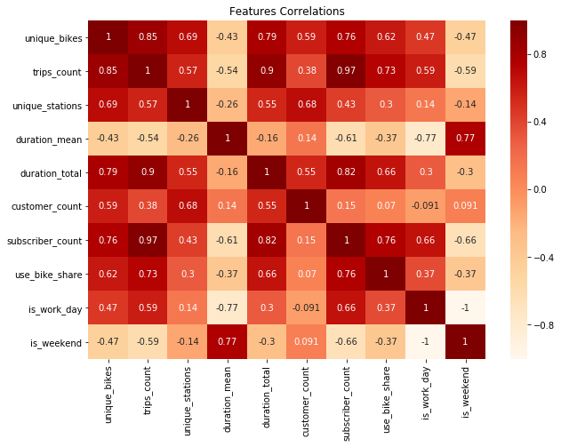

```python
plt.figure(figsize = (FIG_WIDTH_MEDIUM,FIG_HEIGHT))
sns.heatmap(df_agg_by_date.corr(), cmap = 'OrRd', annot=True);
plt.title('Features Correlations');
```

Wen looking at the correlation heatmap we can see some obvious ones like more bkies used, more trips we have and if we have more trips they toal duration of trips will increase.  
Because a lot of trips are made by Subscribers, this implies a positive correlation with trips and their duration.  
The mean duration of trips is correlated to the fact it is weeekend or not. During weekends trips seems to take longer. This result is also confirmed when ploting the distributions of trips durations during the weekends versus work days

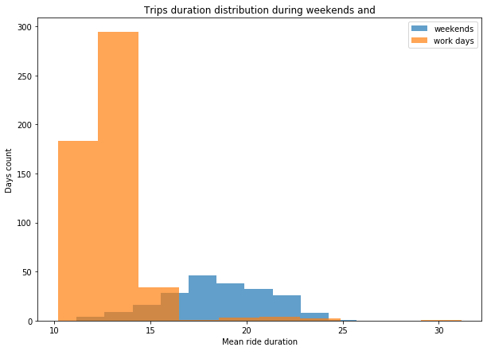

```python
plt.figure(figsize = (FIG_WIDTH_MEDIUM,FIG_HEIGHT))
plt.hist(df_agg_by_date[df_agg_by_date['is_weekend'] == 1]['duration_mean'], alpha=0.7, label='weekends')
plt.hist(df_agg_by_date[df_agg_by_date['is_weekend'] == 0]['duration_mean'], alpha=0.7, label='work days')
plt.title('Trips duration distribution during weekends and')
plt.xlabel('Mean ride duration')
plt.ylabel('Days count');
plt.legend();
```

### Multivariate

**How rides daily total duration look for each user types?**

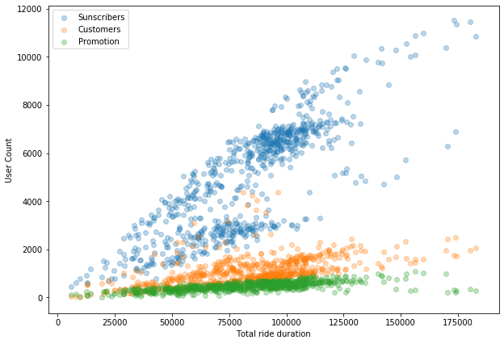

```python
plt.figure(figsize = (FIG_WIDTH_MEDIUM,FIG_HEIGHT))

plt.scatter(x=df_agg_by_date['duration_total'], y=df_agg_by_date['subscriber_count'], label='Sunscribers', alpha=0.3)
plt.scatter(x=df_agg_by_date['duration_total'], y=df_agg_by_date['customer_count'], label='Customers', alpha=0.3)
plt.scatter(x=df_agg_by_date['duration_total'], y=df_agg_by_date['use_bike_share'], label='Promotion', alpha=0.3)
plt.legend()
plt.xlabel('Total ride duration')
plt.ylabel('User Count');
```

The relation between rides total duration and the customers/subscribers count has some positive correlation, but there are some outliers when customer count spikes but the total duration doesn't increase as much, probably they take very short rides.

**What is the relation between some of the dataset feature?**

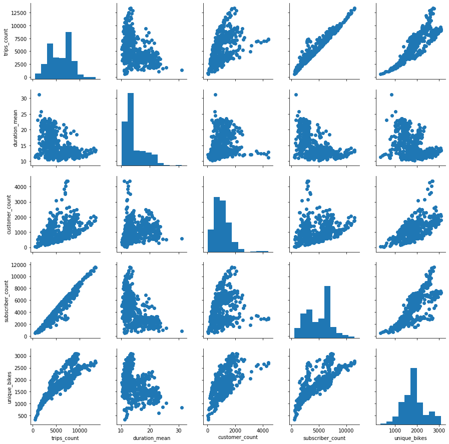

```python
g = sns.PairGrid(data = df_agg_by_date,
                 vars = ['trips_count', 'duration_mean', 'customer_count', 'subscriber_count', 'unique_bikes'])
g.map_diag(plt.hist)
g.map_offdiag(plt.scatter);
```

The pairplots show us there some positive correlations: trips_count and unique_bkies, subscribers_count and trips_count.

## Save all results

```python
df_clean.to_csv(clean_file, index=False, compression='gzip')
```

```python
df_aggregated.to_csv(local_path + 'gobike_agg1.csv.gz', index=False, compression='gzip')
```

```python
df_agg_by_date.to_csv(local_path + 'gobike_agg2.csv.gz', index=False, compression='gzip')
```

### Build slideshow

```python
!jupyter nbconvert slide_deck.ipynb --to slides --template output_toggle
```

```
[NbConvertApp] Converting notebook slide_deck.ipynb to slides
[NbConvertApp] Writing 389070 bytes to slide_deck.slides.html
```

```python
# !pip install pandas==0.25.3 matplotlib==3.1.2
```